# dna_methylation

Charles

Last compiled on 31 Juli, 2023

## Introduction

Epigenetic mechanisms regulate gene expression. Certain technologies enable us measure some epigentic endpoints. One example is DNA methylation. DNA methylation is a chemical process that occurs around genes and which is capable of silencing gene expression. In this project, I will analyse DNA methylation data for the whole genome and relate it to phenotypic variation.

It has been studies that when part of a genome is methylated, the gene close to it is not expressed. It is inherited at mitosis.

Methylation often occurs at CpG islands. A **CpG** is a C, followed by a G but from the $5^1$ end to the $3^1$ end. When one DNA strand is methylated, so is the other. if we also have a CpG on one strand, we have it as well on the other strand.When DNA replicates, its methylation characteristics are preserved.

In this project I will be performing exploratory data analysis on public DNA methylation data.

## Load libraries

```r
library(BSgenome.Hsapiens.UCSC.hg19) # human genome package
```

## Exploratory data analysis

### Calculate GC content on chromosome 22.

The GC-content are the proportion of bases that are either “G” or “C”.

#### Subset gene sequence of chr22

```r
# subset chr22
chr22 <- Hsapiens[["chr22"]]

# select start region
s <- subseq(chr22,
            start = 23456789,
            width = 1000)
print(as.character(s))
```

```
## [1] "AGTCACTTGTGCCTGGGTGTGGGGACTAAGCTGTCCATGTGTATCCCACATCAGCCCTCA…"
```

#### Calculate the GC content

```r
cg_prop <- letterFrequency(s,
                letters = "CG", # specify string of interest
                as.prob = TRUE) # specify results output
cg_prop
```

```
##   C|G
## 0.583
```

The results show that GC content of the slected resion of chr22 is **58.3%**.

### Calculate the number of CpGs

```r
n_cg <- countPattern(s,
                     pattern = "CG")
n_cg
```

```
## [1] 10
```

There are 10 CpGs in the DNA string of interest on chr22.

### Calculate the number of GpCs

```r
n_gc <- countPattern(s,
                     pattern = "GC")
n_gc
```

```
## [1] 65
```

There are 65 GpCs in the DNA string of interest on chr22.

## CpG islands Assessment

CpG islands are regions of the DNA with higher concentrations of CpGs compared to other areas of the genome.

### Bioconductor AnnotationHub package

This package permits us to explore available annotations.

```r
library(AnnotationHub)
ah <- AnnotationHub()
head(ah)
```

```
## AnnotationHub with 6 records
## # snapshotDate(): 2021-10-20
## # $dataprovider: UCSC
## # $species: Homo sapiens
## # $rdataclass: GRanges
## # additional mcols(): taxonomyid, genome, description,
## #   coordinate_1_based, maintainer, rdatadateadded, preparerclass, tags,
## #   rdatapath, sourceurl, sourcetype
## # retrieve records with, e.g., 'object[["AH5012"]]'
##
##            title
##   AH5012 | Chromosome Band
##   AH5013 | STS Markers
##   AH5014 | FISH Clones
##   AH5015 | Recomb Rate
##   AH5016 | ENCODE Pilot
##   AH5017 | Map Contigs
```

### Subset these to just the databases related to the hg19 genome.

```r
ah <- subset(ah,ah$genome=="hg19")
head(ah)
```

```
## AnnotationHub with 6 records
## # snapshotDate(): 2021-10-20
## # $dataprovider: UCSC
## # $species: Homo sapiens
## # $rdataclass: GRanges
## # additional mcols(): taxonomyid, genome, description,
## #   coordinate_1_based, maintainer, rdatadateadded, preparerclass, tags,
## #   rdatapath, sourceurl, sourcetype
## # retrieve records with, e.g., 'object[["AH5012"]]'
##
##            title
##   AH5012 | Chromosome Band
##   AH5013 | STS Markers
##   AH5014 | FISH Clones
##   AH5015 | Recomb Rate
##   AH5016 | ENCODE Pilot
##   AH5017 | Map Contigs
```

The table above shows the databses with annotations related to the hg19 genome.

### Query gene annotations

```r
query(ah, "genes")
```

```
## AnnotationHub with 64 records
## # snapshotDate(): 2021-10-20
## # $dataprovider: UCSC, BroadInstitute
## # $species: Homo sapiens
## # $rdataclass: GRanges, data.frame
## # additional mcols(): taxonomyid, genome, description,
## #   coordinate_1_based, maintainer, rdatadateadded, preparerclass, tags,
## #   rdatapath, sourceurl, sourcetype
## # retrieve records with, e.g., 'object[["AH5036"]]'
##
##             title
##   AH5036  | UCSC Genes
##   AH5037  | Old UCSC Genes
##   AH5040  | RefSeq Genes
##   AH5042  | MGC Genes
##   AH5044  | Vega Genes
##   ...       ...
##   AH25812 | wgEncodeSunyAlbanyGeneStK562T7tagRbpAssocRna.broadPeak.gz
##   AH25813 | wgEncodeSunyAlbanyGeneStK562T7tagRbpAssocRnaV2.broadPeak.gz
##   AH49015 | 57epigenomes.N.pc.gz
##   AH49016 | 57epigenomes.N.rb.gz
##   AH49019 | 57epigenomes.RPKM.pc.gz
```

### Identifing the record ID used by AnnotationHub for hg19 CpG Islands

```r
cgi_id <- query(ah,"cpg")
head(cgi_id)
```

```
## AnnotationHub with 2 records
## # snapshotDate(): 2021-10-20
## # $dataprovider: UCSC
## # $species: Homo sapiens
## # $rdataclass: GRanges
## # additional mcols(): taxonomyid, genome, description,
## #   coordinate_1_based, maintainer, rdatadateadded, preparerclass, tags,
## #   rdatapath, sourceurl, sourcetype
## # retrieve records with, e.g., 'object[["AH5086"]]'
##
##            title
##   AH5086 | CpG Islands
##   AH5096 | Evo Cpg
```

The results show that the record ID used by AnnotationHub for hg19 CpG Islands is **AH5086**.

### Retrive annotations related to record ID AH5086

```r
cgi <- ah[["AH5086"]]
```

### Calculate the number of CpGs in cgi

```r
length(cgi)
```

```
## [1] 28691
```

### Extract sequences of each CpG islands

```r
library(BSgenome.Hsapiens.UCSC.hg19)

cgiseq <- getSeq(Hsapiens, cgi)
head(cgiseq)
```

```
## DNAStringSet object of length 6:
##     width seq
## [1]  1075 CGCCTCTTTGGGACCGCGGTTTATACTTTCGAAG...CTCCAGCCCTACGCCTTGACCCGCTTTCCTGCG
## [2]   439 CGCAGTGAGGCGAGAGCTAGCTGGGCGTGGAGAG...CTTCGGGACGATTTGGGCCTGCGGAGGCCGCCG
## [3]   439 CGGCGGCCTCCGCAGGCCCAAATCGTCCCGAAGT...TCTCCACGCCCAGCTAGCTCTCGCCTCACTGCG
## [4]  1013 CGGAAGATCGAGCGCTCTGGGTGGACTTACGGCC...TGCTGGCCACAGAGAACCCGCGTGCGCCGGCCG
## [5]  1271 CGTGAGCTGCTGAGACGGCACCCGCGTGAGTGTC...GGCACCCGTGTGAGTGTCGCAGTTTCCACACCG
## [6]   895 CGGTGTGGAAACTGCGACACTCACGCGGGTGCCA...ACACTCACGCGGGTGCCGTCTCAGCAGCTCACG
```

### Computing the proportion of Cs for each island and the median.

```r
prop_c <- letterFrequency(cgiseq, # sequences of cpgs
                            letters = "C", # letter of interest
                            as.prob = TRUE) # return proportions
median(prop_c)
```

```
## [1] 0.3418675
```

The results show that the median proportion of Cs in the CpG sequences is 0.3418675.

### Computing the proportion of Gs for each island and the median.

```r
prop_g <- letterFrequency(cgiseq, # sequences of cpgs
                            letters = "G", # letter of interest
                            as.prob = TRUE) # return proportions
median(prop_g)
```

```
## [1] 0.342723
```

### Calculate the median of observed number of CpGs by the expected number of CpGs.

```r
res <- alphabetFrequency(cgiseq)
L <- rowSums(res)
exp_cg <- L * prop_c * prop_g
obs_cg <- vcountPattern(pattern = "CG",
                   subject = cgiseq)
cpgoe <- obs_cg / exp_cg
median(cpgoe)
```

```
## [1] 0.8316008
```

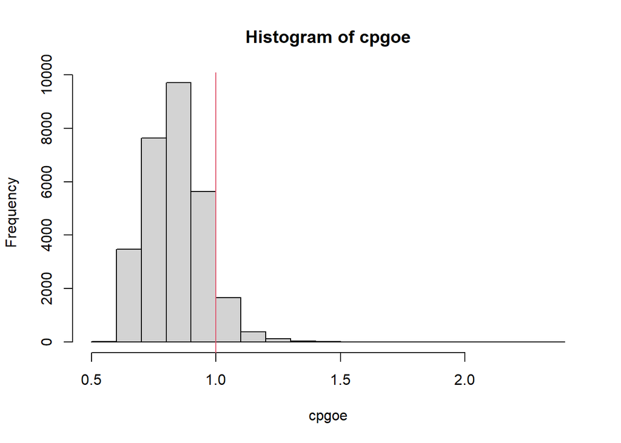

```r
# we can look at a histogram
hist(cpgoe)
abline(v=1, col=2)
```

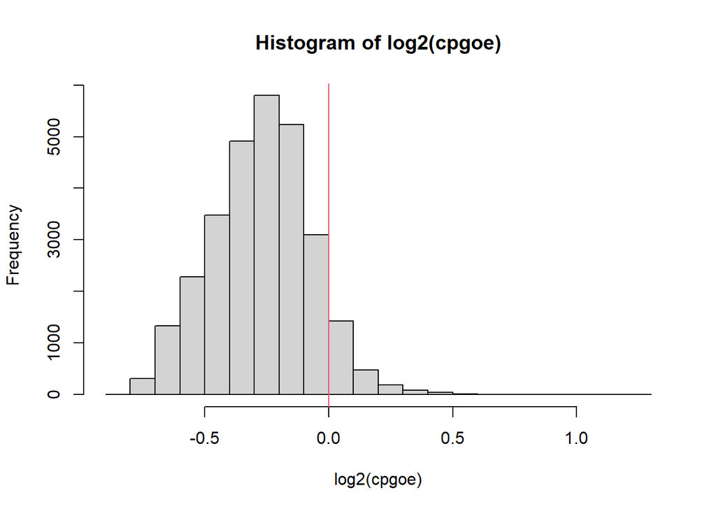

```r
# because these are ratios, looking at the log is better
hist(log2(cpgoe))
abline(v=0, col=2)
```

The results show that the ratio of observed to expected cpgs is 0.8316008. This shows that the expected number of CpGs is higher than the actually observed number of cpgs.

### Calculate the median of observed number of GpCs by the expected number of CpGs.

```r
obs_gc <- vcountPattern(pattern = "GC",
                   subject = cgiseq)
gpcoe <- obs_gc / exp_cg
median(gpcoe)
```

```
## [1] 1.016737
```

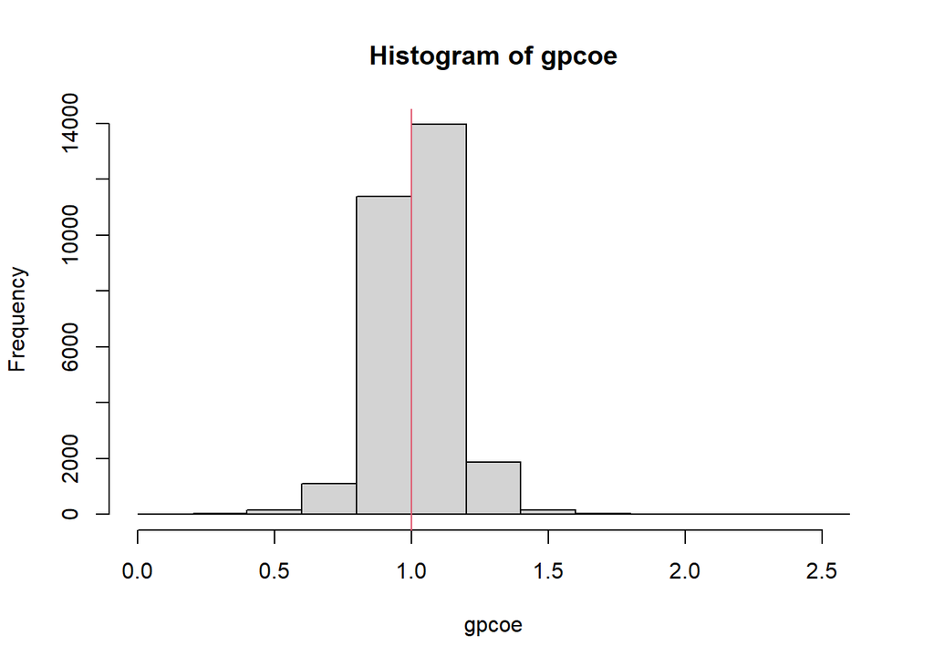

```r
# we can look at a histogram
hist(gpcoe)
abline(v=1, col=2)
```

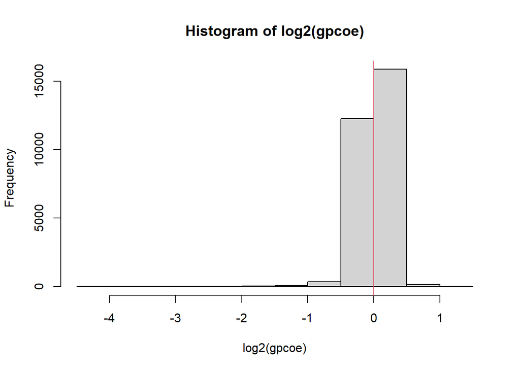

```r
# because these are ratios, looking at the log is better
hist(log2(gpcoe))
abline(v=0, col=2)
```

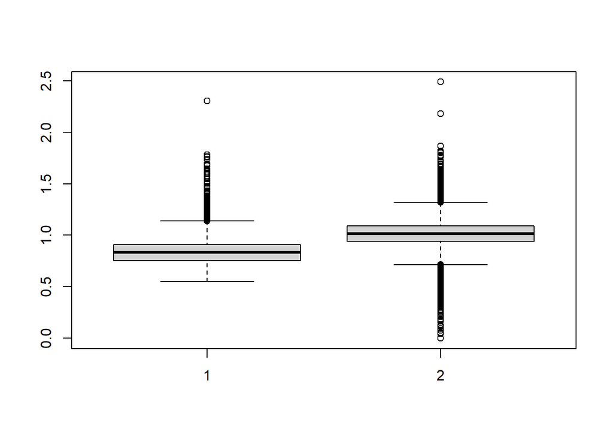

```r
### We can look at a histogram
boxplot(list(cpgoe,gpcoe))
```

The results show that the ratio of observed to expected cpgs is 1.0167369. This shows that the expected number of GpCs is less than the actually observed number of gpcs.

### Analyse CpGs in regions that are not islands

To achieve this, we will shift the islands by 20000 nucleotides and restrict analysis to mapped chromosomes.

```r
chr2use <- seqlevels(cgi)[1:24]
index <- which(seqnames(cgi) %in% chr2use)

# define the non-cpg islands by shifting known ones by 20K nucleotides
noncgi <- shift(cgi[index], 20000)

# some of these regions contain repeats or are unmapped, so we remove regions that have 0 Cs or 0 Gs.

library(BSgenome.Hsapiens.UCSC.hg19)

noncgiseq <- getSeq(Hsapiens, noncgi)
nullres <- alphabetFrequency(noncgiseq)
keepIndex <- nullres[,"G"]>0 &  nullres[,"C"]>0 & nullres[,"N"]==0
nullres <- nullres[keepIndex, ]
noncgiseq <- noncgiseq[keepIndex]
```

### Analyse median of CpGs in regions that are not islands

```r
res <- alphabetFrequency(noncgiseq)
L <- rowSums(res)
prop_c <- res[, "C"] / L
prop_g <- res[, "G"] / L
expected_cg <- L * prop_c * prop_g
obs_cg <- vcountPattern(noncgiseq,
                        pattern = "CG")
cpgoe <- obs_cg / expected_cg
median(cpgoe)
```

```
## [1] 0.2490224
```

The results show that the median of the ratio of the number of observed CpGs to the number of expected CpGs is 0.2490224. This shows that in these regions the CpG-poor areas also have a small ratio of number of observed CpGs to number of expected CpGs.